# Now-casting.com

### Objectives

- provide a brief summary of our exploratory analysis of the nowcasts provided by now-casting.com.
- point out the series that seem to work well, and the one for which the nowcasts may look less efficient.

### Euro area, GDP growth

- we use simple visualizations and statistical measures to obtain preliminary assessments of the quality of the forecasts.
- a ground-truth or "actual" series is used for comparison with the nowcasts. It is real GDP growth (Q-to-Q) from OECD.
- first the actual value is plotted against the nowcasts at different timelines (6 months before release, 3 months before release, 1 month before release, at release, 1 month after release, 3 month after release).
- basic correlations are also calculated between the actual series and the different nowcasts.
- finally, the average root mean square forecast error (RMSFE) is estimated for the different nowcasts timelines (averaging is realised over the sample periods).

```python
# numpy
import numpy as np
import numpy.matlib
# matlplotlib
import matplotlib.pyplot as plt
# seaborn
import seaborn as sns
# pandas
import pandas as pd
# path
path = "/home/romain/nowcasting_report"
```

At first, compare the nowcasts at different timelines with the actual values.

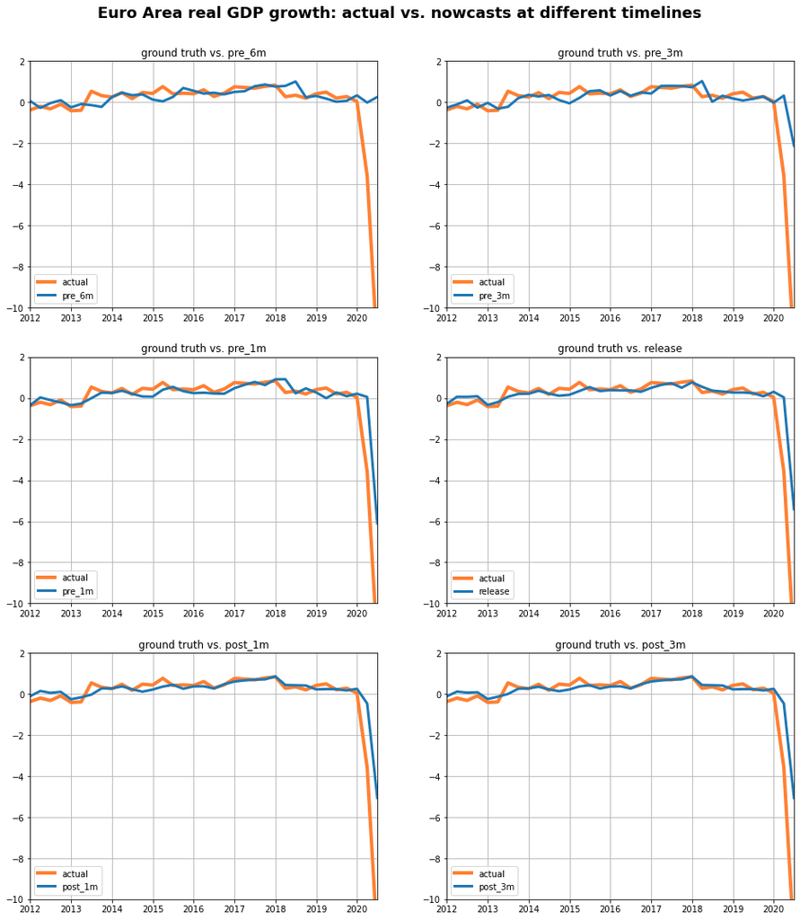

```python
# import and format data
df_ea = pd.read_csv(path + "/nowcast_Euro_Area.csv", delimiter=',',header=None)
df_ea.index=["actual", "pre_6m", "pre_3m", "pre_1m", "release", "post_1m", "post_3m"]
df_ea.columns=pd.date_range(start='12/2011', end='7/2020',freq='Q')
df_ea=df_ea.transpose()
df_ea_no2020 = df_ea.loc['2011-12-31':'2019-12-31', :]
# first overall plot: all series vs ground truth
fig_1 = plt.figure(figsize=(16,18))
plt.suptitle('Euro Area real GDP growth: actual vs. nowcasts at different timelines', y=0.93, fontsize=18, fontweight='semibold')
for i in range(6):
    plt.subplot(3,2,i+1)
    plt.plot(df_ea.index, df_ea[df_ea.columns[0]], color=(1, 0.5, 0.2), linewidth=4, label = df_ea.columns[0])
    plt.plot(df_ea.index, df_ea[df_ea.columns[i+1]], linewidth=3, label = df_ea.columns[i+1])
    plt.ylim(-10,2)
    plt.xlim(df_ea.index[0],df_ea.index[-1])
    plt.legend()
    plt.grid(True)
    plt.title('ground truth vs. ' + df_ea.columns[i+1])
plt.show()
```

Overall, the nowcasts look quite good. The latest ones look really close to the actual values.

Then, basic correlations are computed between the nowcasts and the ground truth series.

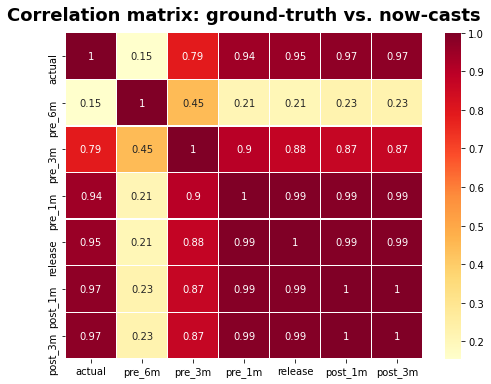

```python
# calculate correlations
correlation_matrix = np.corrcoef(df_ea.transpose())
# create correlation matrix figure
fig_2 = plt.figure(figsize=(8,6))
plt.title('Correlation matrix: ground-truth vs. now-casts', y=1.02, fontsize=18, fontweight='semibold')
sns.heatmap(correlation_matrix, annot = True, linewidths=.5, cmap='YlOrRd', xticklabels=df_ea.columns, yticklabels=df_ea.columns);
plt.show()
```

The correlations between the actual series and the nowcasts also look good. The correlation for the earliest nowcast is low (0.15 for 6 month before release) but then increases quickly to more than 0.95.

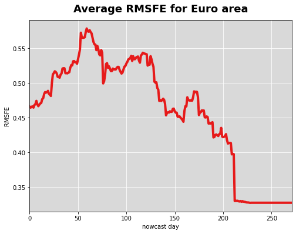

```python
# import and process data
df_ea_daily = pd.read_csv(path + "/daily_gdp_ea.csv", delimiter=',',header=None)
df_ea_daily.columns=pd.date_range(start='12/2011', end='4/2020',freq='Q')
as_list = df_ea_daily.index.tolist()
idx = as_list.index(272)
as_list[idx] = 'actual'
df_ea_daily.index = as_list
# compute RMSE
actual_row = df_ea_daily.loc[['actual']].values[0]
df_rmse = df_ea_daily.apply(lambda row: (row - actual_row)**2, axis=1)[0:-1].mean(axis=1).to_frame().rename(columns={0: "RMSE"})
# plot figure
fig_3 = plt.figure(figsize=(8,6))
ax = plt.gca()
plt.plot(df_rmse.index, df_rmse['RMSE'], color=(0.9, 0.1, 0.1), linewidth=4);
plt.title('Average RMSFE for Euro area', y=1.02, fontsize=18, fontweight='semibold')
ax.set_facecolor(color=(0.85, 0.85, 0.85))
plt.xlim(df_rmse.index[0],df_rmse.index[-1])
plt.xlabel('nowcast day')
plt.ylabel('RMSFE')
plt.grid(True, color=(1, 1, 1))
plt.show()
```

Finally, the RMSFE is plot (using the OECD GDP series as reference for computinfg the error). This plot replicates closely the one provided in the information materials presentation of Now-casting.com, slide 14. The initial rise in RMSFE observed here is due to the fact nowcasts are considered earlier (6 months before release against 3 month only in the presentation). Aside from this initial increase in RMSFE, the RMSFE steadily decreases, as expected when more information arrives.

Overall, the results for the Euro Area are quite convincing!

### United States, GDP growth

The same exercise is conducted for the United States.

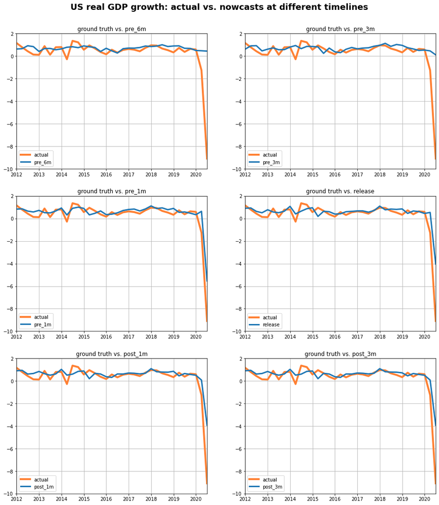

```python
# import and format data
df_us = pd.read_csv(path + "/nowcast_US.csv", delimiter=',',header=None)
df_us.index=["actual", "pre_6m", "pre_3m", "pre_1m", "release", "post_1m", "post_3m"]
df_us.columns=pd.date_range(start='12/2011', end='7/2020',freq='Q')
df_us=df_us.transpose()
df_us_no2020 = df_us.loc['2011-12-31':'2019-12-31', :]
# first overall plot: all series vs ground truth
fig_4 = plt.figure(figsize=(16,18))
plt.suptitle('US real GDP growth: actual vs. nowcasts at different timelines', y=0.93, fontsize=18, fontweight='semibold')
for i in range(6):
    plt.subplot(3,2,i+1)
    plt.plot(df_us.index, df_us[df_us.columns[0]], color=(1, 0.5, 0.2), linewidth=4, label = df_us.columns[0])
    plt.plot(df_us.index, df_us[df_us.columns[i+1]], linewidth=3, label = df_us.columns[i+1])
    plt.ylim(-10,2)
    plt.xlim(df_us.index[0],df_us.index[-1])
    plt.legend()
    plt.grid(True)
    plt.title('ground truth vs. ' + df_us.columns[i+1])
plt.show()
```

The nowcasts seem again to be fairly close to the actual values, though they look somewhat smoother. The earliest forecasts are the least convincing and apparently fail to adequately capture the COVID. It also noteworthy that the nowcasts one month before release capture the COVID better than the ones 3 months after release.

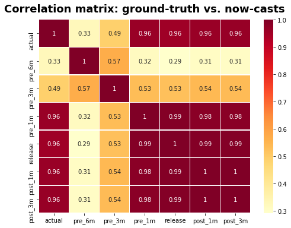

```python
# calculate correlations
correlation_matrix = np.corrcoef(df_us.transpose())
# create correlation matrix figure
fig_5 = plt.figure(figsize=(8,6))
plt.title('Correlation matrix: ground-truth vs. now-casts', y=1.02, fontsize=18, fontweight='semibold')
sns.heatmap(correlation_matrix, annot = True, linewidths=.5, cmap='YlOrRd', xticklabels=df_ea.columns, yticklabels=df_ea.columns);
plt.show()
```

The pattern is similar to that of the Euro Area: earlier forecasts display low correlation, while later ones display really high correlations.

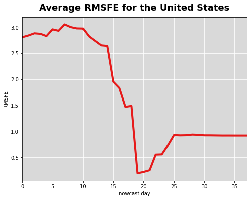

```python
# import and process data
df_us_weekly = pd.read_csv(path + "//weekly_gdp_us.csv", delimiter=',',header=None)
df_us_weekly.columns=pd.date_range(start='12/2011', end='7/2020',freq='Q')
as_list = df_us_weekly.index.tolist()
idx = as_list.index(38)
as_list[idx] = 'actual'
df_us_weekly.index = as_list
# compute RMSE
actual_row = df_us_weekly.loc[['actual']].values[0]
df_rmse = df_us_weekly.apply(lambda row: (row - actual_row)**2, axis=1)[0:-1].mean(axis=1).to_frame().rename(columns={0: "RMSE"})
# plot figure
fig_6 = plt.figure(figsize=(8,6))
ax = plt.gca()
plt.plot(df_rmse.index, df_rmse['RMSE'], color=(0.9, 0.1, 0.1), linewidth=4);
plt.title('Average RMSFE for the United States', y=1.02, fontsize=18, fontweight='semibold')
ax.set_facecolor(color=(0.85, 0.85, 0.85))
plt.xlim(df_rmse.index[0],df_rmse.index[-1])
plt.xlabel('nowcast day')
plt.ylabel('RMSFE')
plt.grid(True, color=(1, 1, 1))
plt.show()
```

When looking at RMSFE, the pattern becomes unexpected. The nowcast RMSFE is first steadily declining, then getting back up roughly one month before release. This goes against the intuition that more information should produce more accurate forecasts.

After some more exploration, it seems that this surprising result might be - at least partially - due to the COVID. Indeed, by just excluding 2020q2 from the sample, the plot changes significantly:

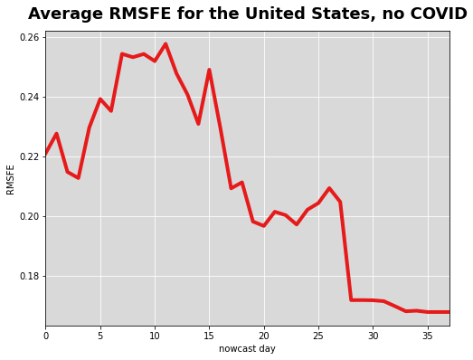

```python
# import and process data
df_us_weekly_nocovid = df_us_weekly.iloc[:,:-1]
# compute RMSE
actual_row = df_us_weekly_nocovid.loc[['actual']].values[0]
df_rmse = df_us_weekly_nocovid.apply(lambda row: (row - actual_row)**2, axis=1)[0:-1].mean(axis=1).to_frame().rename(columns={0: "RMSE"})
# plot figure
fig_7 = plt.figure(figsize=(8,6))
ax = plt.gca()
plt.plot(df_rmse.index, df_rmse['RMSE'], color=(0.9, 0.1, 0.1), linewidth=4);
plt.title('Average RMSFE for the United States, no COVID', y=1.02, fontsize=18, fontweight='semibold')
ax.set_facecolor(color=(0.85, 0.85, 0.85))
plt.xlim(df_rmse.index[0],df_rmse.index[-1])
plt.xlabel('nowcast day')
plt.ylabel('RMSFE')
plt.grid(True, color=(1, 1, 1))
plt.show()
```

Now the RMSE steadily declines without rising again anymore at the end of the sample. It thus seems that the COVID represents a large outlier that it is sufficient to affect the average RMFSE.

This conclusion is in line with the visualisation of the COVID period on the now-casting.com website for the United States:

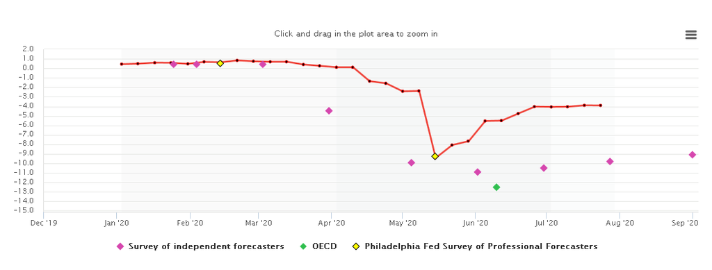

```python
import base64, io, IPython
from PIL import Image as PILImage

image = PILImage.open('/home/romain/nowcasting_report/covid_us_gdp.png')

output = io.BytesIO()
image.save(output, format='PNG')
encoded_string = base64.b64encode(output.getvalue()).decode()

html = '<img src="data:…"/>'.format(encoded_string)
IPython.display.HTML(html)
```

Overall, the value of -9% produced by the nowcasts in May seems closer to the ground truth than the value of -4% predicted by the updated nowcasts in July/August. Other surveys also seem to disagree with the nowcasts here, predicting rather a decline around -10%. This suggests that the model may struggle to account for the COVID effect.

Still, aside from the COVID, the US does exhibit some undesirable results. If instead of excluding just the COVID (2020q2) one excludes the whole year 2020 (hence 2020q1 and 2020q2), the results become poor again. The correlations become fairly low:

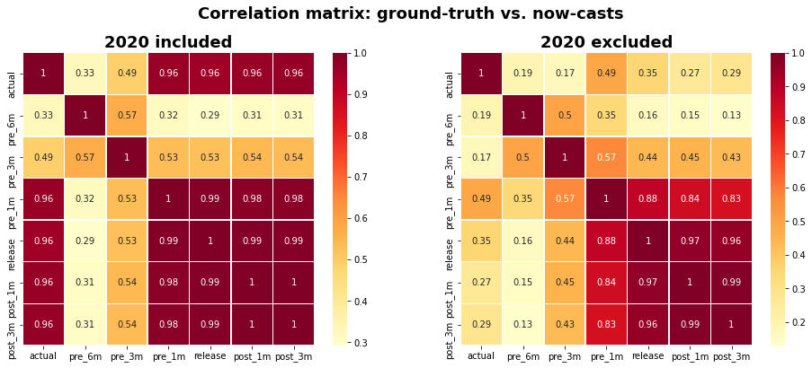

```python
# calculate correlations
correlation_matrix = np.corrcoef(df_us.transpose())
correlation_matrix_no2020 = np.corrcoef(df_us_no2020.transpose())
fig_8 = plt.figure(figsize=(16,6))
plt.suptitle('Correlation matrix: ground-truth vs. now-casts', y=1, fontsize=18, fontweight='semibold')
plt.subplot(1,2,1)
sns.heatmap(correlation_matrix, annot = True, linewidths=.5, cmap='YlOrRd', xticklabels=df_us.columns, yticklabels=df_us.columns);
plt.title('2020 included', y=1.02, fontsize=18, fontweight='semibold')
plt.subplot(1,2,2)
sns.heatmap(correlation_matrix_no2020, annot = True, linewidths=.5, cmap='YlOrRd', xticklabels=df_us.columns, yticklabels=df_us.columns);
plt.title('2020 excluded', y=1.02, fontsize=18, fontweight='semibold')
plt.show()
```

When excluding 2020 from the sample, the correlations between the actual data and the nowcasts become quite low. Also, the correlation actually declines for the most recent nowcasts. The best forecasts are the one obtained 1 month before the release of the data.

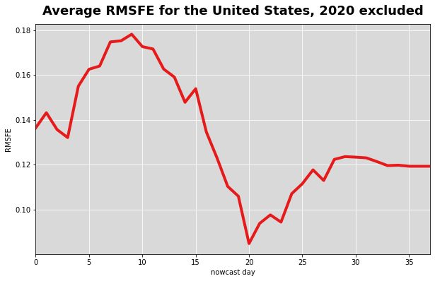

```python
# import and process data
df_us_weekly_no2020 = df_us_weekly.iloc[:,:-2]
# compute RMSE
actual_row = df_us_weekly_no2020.loc[['actual']].values[0]
df_rmse = df_us_weekly_no2020.apply(lambda row: (row - actual_row)**2, axis=1)[0:-1].mean(axis=1).to_frame().rename(columns={0: "RMSE"})
# plot figure
fig_9 = plt.figure(figsize=(10,6))
ax = plt.gca()
plt.plot(df_rmse.index, df_rmse['RMSE'], color=(0.9, 0.1, 0.1), linewidth=4);
plt.title('Average RMSFE for the United States, 2020 excluded', y=1.02, fontsize=18, fontweight='semibold')
ax.set_facecolor(color=(0.85, 0.85, 0.85))
plt.xlim(df_rmse.index[0],df_rmse.index[-1])
plt.xlabel('nowcast day')
plt.ylabel('RMSFE')
plt.grid(True, color=(1, 1, 1))
plt.show()
```

Eventually, one notices that the RMSE starts rising again at the end of the nowcast timeline. This should not happen if more information results in more accurate predictions.

Overall, we found that most other developed economies (Japan, France, Germany, Spain and the United Kingdom) behave in a way that is fairly similar to the Euro Area: the nowcast series look close to the actual series, they display a fairly high correlation (at least for the later nowcasts), and the calculated RMSFE steadily decline as more information obtains. Italy, however, looks less convincing.

### A focus on Italy, GDP growth

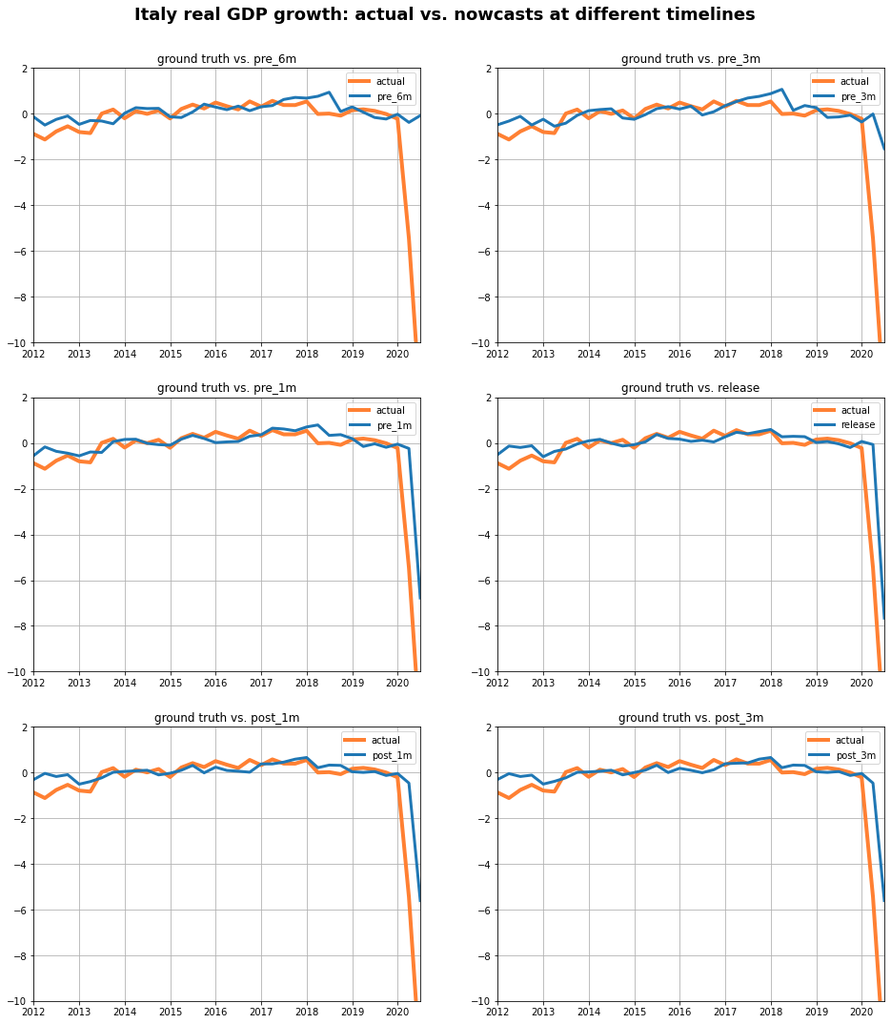

```python
# import and format data
df_it = pd.read_csv(path + "/nowcast_Italy.csv", delimiter=',',header=None)
df_it.index=["actual", "pre_6m", "pre_3m", "pre_1m", "release", "post_1m", "post_3m"]
df_it.columns=pd.date_range(start='12/2011', end='7/2020',freq='Q')
df_it=df_it.transpose()
df_it_no2020 = df_it.loc['2011-12-31':'2019-12-31', :]
# first overall plot: all series vs ground truth
fig_10 = plt.figure(figsize=(16,18))
plt.suptitle('Italy real GDP growth: actual vs. nowcasts at different timelines', y=0.93, fontsize=18, fontweight='semibold')
for i in range(6):
    plt.subplot(3,2,i+1)
    plt.plot(df_it.index, df_it[df_it.columns[0]], color=(1, 0.5, 0.2), linewidth=4, label = df_it.columns[0])
    plt.plot(df_it.index, df_it[df_it.columns[i+1]], linewidth=3, label = df_it.columns[i+1])
    plt.ylim(-10,2)
    plt.xlim(df_it.index[0],df_it.index[-1])
    plt.legend()
    plt.grid(True)
    plt.title('ground truth vs. ' + df_it.columns[i+1])
plt.show()
```

While the plots still reasonably approach the actual values, the model seems to do less well close to te COVID period: not only do the nowcasts seem to be lagging behind the actual values, but also the latest forecasts seem less accurate than those produced one month before release and at release.

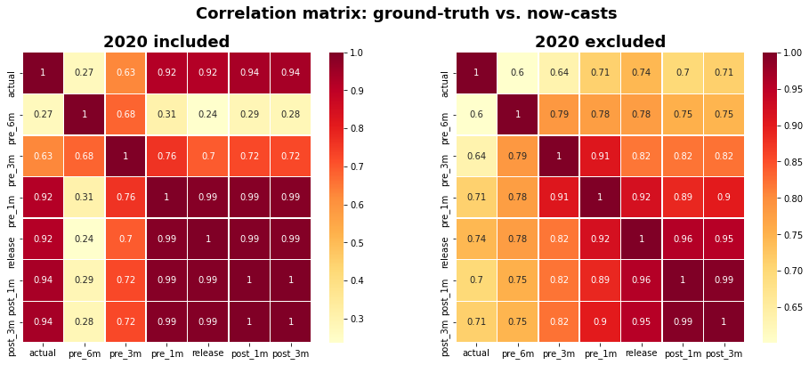

```python
# calculate correlations
correlation_matrix = np.corrcoef(df_it.transpose())
correlation_matrix_no2020 = np.corrcoef(df_it_no2020.transpose())
fig_11 = plt.figure(figsize=(16,6))
plt.suptitle('Correlation matrix: ground-truth vs. now-casts', y=1, fontsize=18, fontweight='semibold')
plt.subplot(1,2,1)
sns.heatmap(correlation_matrix, annot = True, linewidths=.5, cmap='YlOrRd', xticklabels=df_us.columns, yticklabels=df_us.columns);
plt.title('2020 included', y=1.02, fontsize=18, fontweight='semibold')
plt.subplot(1,2,2)
sns.heatmap(correlation_matrix_no2020, annot = True, linewidths=.5, cmap='YlOrRd', xticklabels=df_us.columns, yticklabels=df_us.columns);
plt.title('2020 excluded', y=1.02, fontsize=18, fontweight='semibold')
plt.show()
```

When 2020 is excluded, the correlation does not seem to improve much as later nowcasts are produced. It also remains capped at 0.7, way beow the 0.95 level of the full sample.

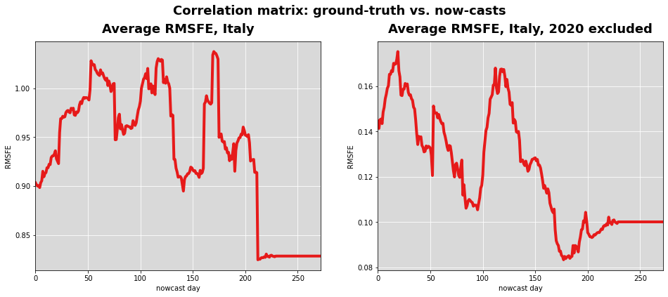

```python
# import and process data
df_it_daily = pd.read_csv(path + "/daily_gdp_italy.csv", delimiter=',',header=None)
df_it_daily.columns=pd.date_range(start='12/2011', end='4/2020',freq='Q')
as_list = df_it_daily.index.tolist()
idx = as_list.index(273)
as_list[idx] = 'actual'
df_it_daily.index = as_list

# compute RMSE
actual_row = df_it_daily.loc[['actual']].values[0]
df_rmse = df_it_daily.apply(lambda row: (row - actual_row)**2, axis=1)[0:-1].mean(axis=1).to_frame().rename(columns={0: "RMSE"})
fig_12 = plt.figure(figsize=(16,6));
plt.suptitle('Correlation matrix: ground-truth vs. now-casts', y=1, fontsize=18, fontweight='semibold')
ax1 = plt.subplot(1,2,1);
plt.plot(df_rmse.index, df_rmse['RMSE'], color=(0.9, 0.1, 0.1), linewidth=4);
plt.title('Average RMSFE, Italy', y=1.02, fontsize=18, fontweight='semibold')
ax1.set_facecolor(color=(0.85, 0.85, 0.85))
plt.xlim(df_rmse.index[0],df_rmse.index[-1])
plt.xlabel('nowcast day')
plt.ylabel('RMSFE')
plt.grid(True, color=(1, 1, 1))

# import and process data
df_it_daily_no2020 = df_it_daily.iloc[:,:-1]

# compute RMSE
actual_row = df_it_daily_no2020.loc[['actual']].values[0]
df_rmse = df_it_daily_no2020.apply(lambda row: (row - actual_row)**2, axis=1)[0:-1].mean(axis=1).to_frame().rename(columns={0: "RMSE"})
ax2 = plt.subplot(1,2,2);
plt.plot(df_rmse.index, df_rmse['RMSE'], color=(0.9, 0.1, 0.1), linewidth=4);
plt.title('Average RMSFE, Italy, 2020 excluded', y=1.02, fontsize=18, fontweight='semibold')
ax2.set_facecolor(color=(0.85, 0.85, 0.85))
plt.xlim(df_rmse.index[0],df_rmse.index[-1])
plt.xlabel('nowcast day')
plt.ylabel('RMSFE')
plt.grid(True, color=(1, 1, 1))
plt.show();
```

For the full sample (left plot), the RMSFE behave strangely. It is overall declining, but reverts to higher values quite a few times, unlike what would be expected as more information becomes available. It starts dropping for good only after the first release.

When 2020 is excluded from the sample, the RMSFE looks even worse. It starts increasing again at the date of release, before it reaches a plateau roughly two months after release. The increase following the release is clearly at odd with the expected improvement as more information gets available.

### Analysis on other series

Now-casting.com also provided a number of non GDP series for the Euro Area. To obtain a broader overview of the dataset, some of these series were explored, with a similar methodology. Some yielded good results overall, while some produced unexpected results. A selection of these results are developed below.

### business climate indicator

This is an example of a series for which the model works well.

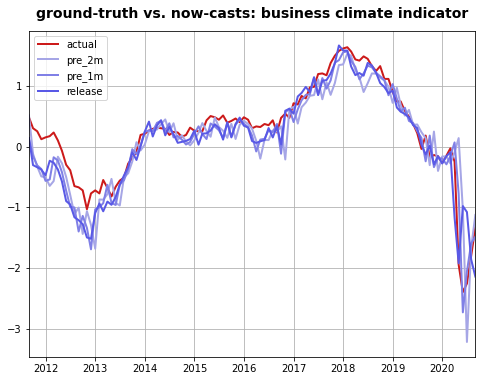

```python
# import and process data
df_climate = pd.read_csv(path + "/business_climate_indicator.csv", delimiter=',',header=None)
df_climate.columns = pd.date_range(start='8/2011', end='9/2020',freq='M')
df_climate_short = df_climate.iloc[[0,1,32,56]]
df_climate_short.index = ["actual", "pre_2m", "pre_1m", "release"]
df_climate_short = df_climate_short.transpose()
df_climate_short_no2020 = df_climate_short.loc['2011-08-31':'2019-12-31', :]
as_list = df_climate.index.tolist()
idx = as_list.index(0)
as_list[idx] = 'actual'
df_climate.index = as_list
df_climate_no2020 = df_climate.loc[:, '2011-08-31':'2019-12-31']
# first overall plot: series vs ground truth
fig_13 = plt.figure(figsize=(8,6))
plt.title('ground-truth vs. now-casts: business climate indicator', y=1.02, fontsize=14, fontweight='semibold')
plt.plot(df_climate_short.index, df_climate_short[df_climate_short.columns[0]], color=(.8, .1, 0.1), linewidth=2, label = df_climate_short.columns[0])
for i in range(1,4):
    plt.plot(df_climate_short.index, df_climate_short[df_climate_short.columns[i]], color=(.8-0.15*i, .8-0.15*i, 0.9), linewidth=2, label = df_climate_short.columns[i])
plt.xlim(df_climate_short.index[0],df_climate_short.index[-1])
plt.legend()
plt.grid(True)
plt.show()
```

The nowcasts follow the actual series quite closely.

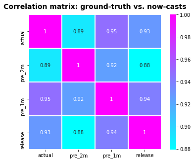

```python
# calculate correlations
correlation_matrix = np.corrcoef(df_climate_short.transpose())
# create correlation matrix figure
fig_14 = plt.figure(figsize=(6,5))
plt.title('Correlation matrix: ground-truth vs. now-casts', y=1.02, fontsize=14, fontweight='semibold')
sns.heatmap(correlation_matrix, annot = True, linewidths=.5, cmap='cool', xticklabels=df_climate_short.columns, yticklabels=df_climate_short.columns)
plt.show()
```

The correlations are extremely high, showing a good fit of the nowcasts to the data.

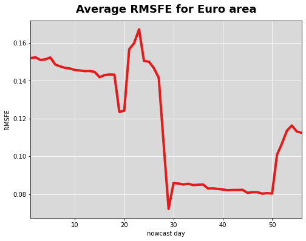

```python
# compute RMSE
actual_row = df_climate.loc[['actual']].values[0]
df_rmse = df_climate.apply(lambda row: (row - actual_row)**2, axis=1)[1:].mean(axis=1).to_frame().rename(columns={0: "RMSE"})
# plot figure
fig_15 = plt.figure(figsize=(8,6))
ax = plt.gca()
plt.plot(df_rmse.index, df_rmse['RMSE'], color=(0.9, 0.1, 0.1), linewidth=4);
plt.title('Average RMSFE for Euro area', y=1.02, fontsize=18, fontweight='semibold')
ax.set_facecolor(color=(0.85, 0.85, 0.85))
plt.xlim(df_rmse.index[0],df_rmse.index[-1])
plt.xlabel('nowcast day')
plt.ylabel('RMSFE')
plt.grid(True, color=(1, 1, 1))
plt.show()
```

The RMSFE is overall declining except over the final periods.

Overall, the model seems good at predicting this series. Other series like construction output or manufacturing turnover also display the same kind of nice behaviour.

Certain series however produce less satisfactory results. Hereafter, two examples are developed: industrial production and car registrations.

### Industrial production

This is an example of a series where the model seems not to do too well.

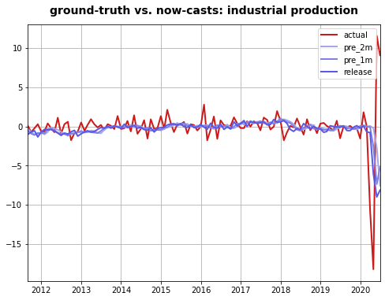

```python
# import and process data
df_industrial = pd.read_csv(path + "/industrial_production.csv", delimiter=',',header=None)
df_industrial.columns = pd.date_range(start='8/2011', end='7/2020',freq='M')
df_industrial_short = df_industrial.iloc[[0,1,32,63,93]]
df_industrial_short.index = ["actual", "pre_2m", "pre_1m", "release", "post_1m"]
df_industrial_short = df_industrial_short.transpose()
df_industrial_short_no2020 = df_industrial_short.loc['2011-08-31':'2019-12-31', :]
as_list = df_industrial.index.tolist()
idx = as_list.index(0)
as_list[idx] = 'actual'
df_industrial.index = as_list
df_industrial_no2020 = df_industrial.loc[:, '2011-08-31':'2019-12-31']
# first overall plot: series vs ground truth
fig_16 = plt.figure(figsize=(8,6))
plt.title('ground-truth vs. now-casts: industrial production', y=1.02, fontsize=14, fontweight='semibold')
plt.plot(df_industrial_short.index, df_industrial_short[df_industrial_short.columns[0]], color=(.8, .1, 0.1), linewidth=2, label = df_industrial_short.columns[0])
for i in range(1,4):
    plt.plot(df_industrial_short.index, df_industrial_short[df_industrial_short.columns[i]], color=(.8-0.15*i, .8-0.15*i, 0.9), linewidth=2, label = df_industrial_short.columns[i])
plt.xlim(df_industrial_short.index[0],df_industrial_short.index[-1])
plt.legend()
plt.grid(True)
plt.show()
```

The fit seems overall correct, but much smoother than the actual variations. Also, the nowcasts for the COVID period seem to be really lagging behind.

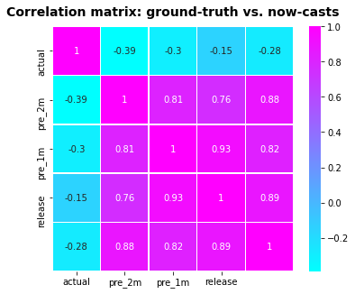

```python
# calculate correlations
correlation_matrix = np.corrcoef(df_industrial_short.transpose())
# create correlation matrix figure
fig_17 = plt.figure(figsize=(6,5))
plt.title('Correlation matrix: ground-truth vs. now-casts', y=1.02, fontsize=14, fontweight='semibold')
sns.heatmap(correlation_matrix, annot = True, linewidths=.5, cmap='cool', xticklabels=df_climate_short.columns, yticklabels=df_climate_short.columns)
plt.show()
```

The correlations look really poor. At any timeline, the correlations between the actual series and the nowcasts are negative. This does not seem to improve as more information is obtained.

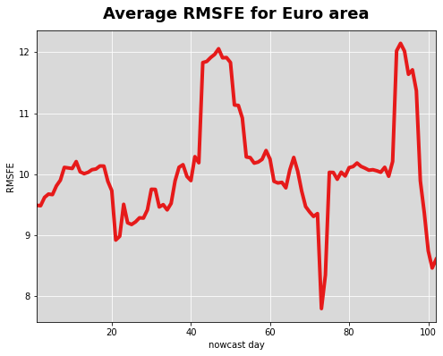

```python
# compute RMSE
actual_row = df_industrial.loc[['actual']].values[0]
df_rmse = df_industrial.apply(lambda row: (row - actual_row)**2, axis=1)[1:].mean(axis=1).to_frame().rename(columns={0: "RMSE"})
# plot figure
fig_18 = plt.figure(figsize=(8,6))
ax = plt.gca()
plt.plot(df_rmse.index, df_rmse['RMSE'], color=(0.9, 0.1, 0.1), linewidth=4);
plt.title('Average RMSFE for Euro area', y=1.02, fontsize=18, fontweight='semibold')
ax.set_facecolor(color=(0.85, 0.85, 0.85))
plt.xlim(df_rmse.index[0],df_rmse.index[-1])
plt.xlabel('nowcast day')
plt.ylabel('RMSFE')
plt.grid(True, color=(1, 1, 1))
plt.show()
```

The RMSFE looks strange. It does overall decline slightly between the beginning and the end of the samples, but the reversion are so many and so large that it does not seem normal.

### New passenger car registrations

This is a final example of a series where things seem to go wrong.

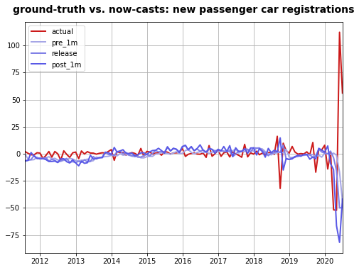

```python
# import and process data
df_car = pd.read_csv(path + "/new_passenger_car_registrations.csv", delimiter=',',header=None)
df_car.columns = pd.date_range(start='7/2011', end='7/2020',freq='M')
df_car_short = df_car.iloc[[0,15,46,75]]
df_car_short.index = ["actual", "pre_1m", "release", "post_1m"]
df_car_short = df_car_short.transpose()
df_car_short_no2020 = df_car_short.loc['2011-08-31':'2019-12-31', :]
as_list = df_car.index.tolist()
idx = as_list.index(0)
as_list[idx] = 'actual'
df_car.index = as_list
df_car_no2020 = df_car.loc[:, '2011-08-31':'2019-12-31']
# first overall plot: series vs ground truth
fig_19 = plt.figure(figsize=(8,6))
plt.title('ground-truth vs. now-casts: new passenger car registrations', y=1.02, fontsize=14, fontweight='semibold')
plt.plot(df_car_short.index, df_car_short[df_car_short.columns[0]], color=(.8, .1, 0.1), linewidth=2, label = df_car_short.columns[0])
for i in range(1,4):
    plt.plot(df_car_short.index, df_car_short[df_car_short.columns[i]], color=(.8-0.15*i, .8-0.15*i, 0.9), linewidth=2, label = df_car_short.columns[i])
plt.xlim(df_car_short.index[0],df_car_short.index[-1])
plt.legend()
plt.grid(True)
plt.show()
```

The fit does not look extremely bad, but there seems to be some lag in the response of the nowcasts, which is especially obvious for the COVID period.

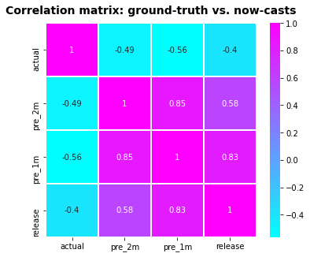

```python
# calculate correlations
correlation_matrix = np.corrcoef(df_car_short.transpose())
# create correlation matrix figure
fig_20 = plt.figure(figsize=(6,5))
plt.title('Correlation matrix: ground-truth vs. now-casts', y=1.02, fontsize=14, fontweight='semibold')
sns.heatmap(correlation_matrix, annot = True, linewidths=.5, cmap='cool', xticklabels=df_climate_short.columns, yticklabels=df_climate_short.columns)
plt.show()
```

The correlations look poor. They remain significantly negative, even one month after the release.

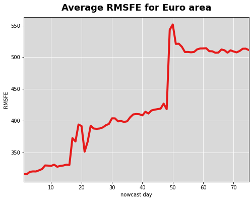

```python
# compute RMSE
actual_row = df_car.loc[['actual']].values[0]
df_rmse = df_car.apply(lambda row: (row - actual_row)**2, axis=1)[1:].mean(axis=1).to_frame().rename(columns={0: "RMSE"})
# plot figure
fig_21 = plt.figure(figsize=(8,6))
ax = plt.gca()
plt.plot(df_rmse.index, df_rmse['RMSE'], color=(0.9, 0.1, 0.1), linewidth=4);
plt.title('Average RMSFE for Euro area', y=1.02, fontsize=18, fontweight='semibold')
ax.set_facecolor(color=(0.85, 0.85, 0.85))
plt.xlim(df_rmse.index[0],df_rmse.index[-1])
plt.xlabel('nowcast day')
plt.ylabel('RMSFE')
plt.grid(True, color=(1, 1, 1))
plt.show()
```

### Conclusions

Adding or excluding 2020 seems to affect the results for certain countries, especially those for which the model performance seems lower in general like the United States or Italy.

For a number of other variables, the performance seems mixed. Some variables achieve really good results, others display average performance, and some series present very unexpected behaviours.

We would be very interested in getting your feedback on these results. In particular, it would be nice if some intuitions could be provided about why certain series behave in an unexpected way.

Possibly, the COVID may represent a major factor of inefficiency. In this case, it would be informative as well to understand why other forecasts methods still manage to achieve fair prediction performances, while the nowcast models struggle a bit more with this event.

```python
FILE = "/home/romain/Téléchargements/Now-casting.com summary report update.html"

with open(FILE, 'r') as html_file:
    content = html_file.read()

# Get rid off prompts and source code
content = content.replace("div.input_area {
	display: none;","div.input_area {
	display: none;\n\tdisplay: none;")
content = content.replace(".prompt {
	display: none;",".prompt {
	display: none;\n\tdisplay: none;")

f = open(FILE, 'w')
f.write(content)
f.close()
```